# Data Visualization with R

- About this course
- Acknowledgements
- Introduction to Graphics
- Base ggplot2
- Creating a Scatter Plot
- Creating a Line Plot
- Creating a Bar Plot
- Creating a Histogram
- Creating a Box Plot
- Creating a Surface Plot
- Advanced ggplot2
- Mapped Aes Customization
- Axes Customization
- Legend Customization
- Facet Customization
- Plot Overall Appearance
- More on Stats
- Other topics
- ggplot2 community
- Presenting Plots

# Axes Customization

```r
require(ggplot2)
require(qdata)
require(scales)
data(bands)
data(brainbod)
```

Axes are more important than one thinks as they provide context for interpreting the displayed data. `ggplot2` displays the axes with defaults that look good in most cases, but you might want to control, for example, the axis scales, the axis labels, the number and placement of tick marks, the tick mark labels and so on.

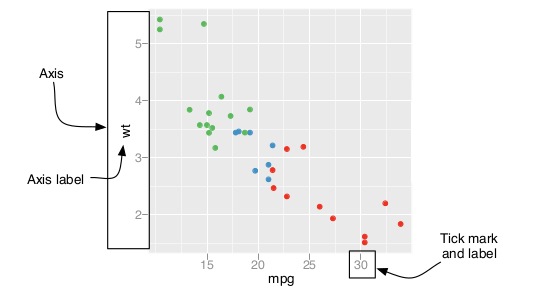

`ggplot2` allows one to handle with the appearance of the axes by using three important elements of its grammar:

- `scales`, which controls the mapping from data to aestethics attributes
- `coordinates`, which describes how data coordinates are mapped to the plane of the graphic
- `themes`, which controls the non-data elements of the plot

In the following paragraphs we will see how to handle with the most common questions about axes customization.

## Swapping x and y axis

Swapping x and y axis is simple if you are generating a scatterplot. If you want to change what goes on the vertical axis and what goes on the horizontal axis you just have to exchange the variables mapped to `x` and `y` aesthetics, as `geom_point()` treats the x- and y-axes equally. However, the same cannot be said for Box Plot which summarize the data along the y-axis or for Line Plots, which move the lines in only one direction along the x-axis. To swap the axis of these and more others geoms which not treats the x- and y-axes equally, you have to use `coord_flip()` function as we learn in *Creating a Bar Plot* chapter.

Let us see an example.  
Consider `bands` dataset. Supposing you are interested in the differences of ink percentage accordingly to the type of press, you can build four box plots to compare distributions.

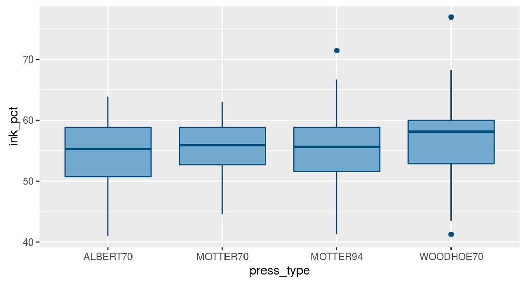

```r
pl_1 <- ggplot(data=bands, aes(x=press_type, y=ink_pct)) +
  geom_boxplot(fill="#74a9cf", colour="#034e7b")
pl_1
```

Swapping the axes the result is:

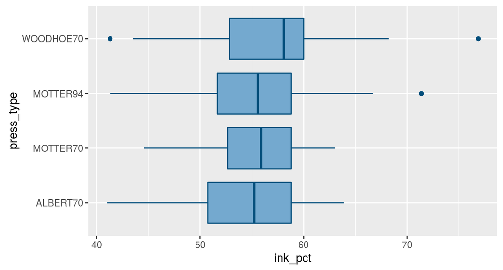

```r
pl_1 +
  coord_flip()
```

## Change axis order

Let us consider a categorical (or discrete) axis with a factor mapped to it.

Sometimes when the axes are swapped, as in the previous example, the order of items will be the reverse of what you want.  
On a graph with standard x- and y-axes, the x items start at the left and go to the right, which corresponds to the normal way of reading, from left to right. When you swap the axes, the items still go from the origin outward, which in this case will be from bottom to top but this conflicts with the normal way of reading, from top to bottom. Sometimes this can be a problem, so it is necessary to reverse the axis order.

This can be done by using `scale_x_discrete()` with `limits` argument set as `rev(levels(...))` in this way:

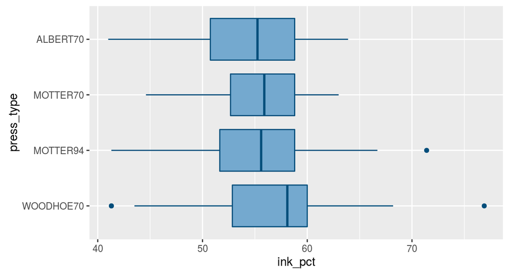

```r
pl_1 +
  coord_flip() +
  scale_x_discrete(limits=rev(levels(bands$press_type)))
```

In general, to manually change the order of items in a categorical (or discrete) axis with a factor mapped to it, you have to specify `limits` argument in `scale_x_discrete()` or `scale_y_discrete()` functions with a vector of the levels in the desired order:

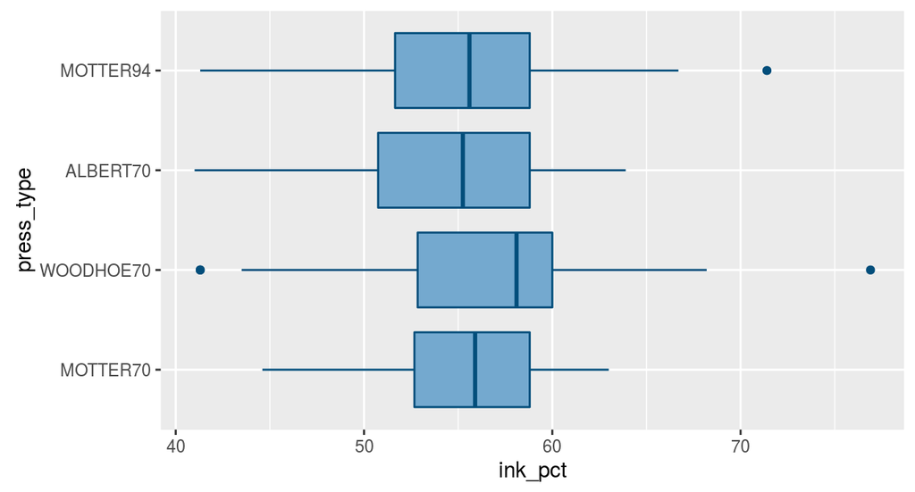

```r
pl_1 +
  coord_flip() +
  scale_x_discrete(limits=c("MOTTER70","WOODHOE70","ALBERT70", "MOTTER94"))
```

You can also omit items with this vector, specifying only the items you want to keep:

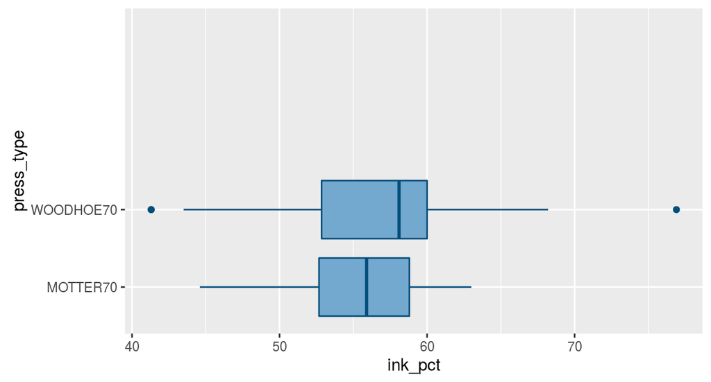

```r
pl_1 +
  coord_flip() +
  scale_x_discrete(limits=c("MOTTER70","WOODHOE70"))
```

There is empty space instead of not displayed `press_type` levels (“ALBERT70”, “MOTTER94”). Maybe it is a bug of 2.1.0 version of `ggplot2`, used to realize this manual.

*Note:* the changes on axis order works also without `coord_flip()` function.

## Setting the Range of a Continuous Axis

`ggplot2` computes the limits of an axes from the range of the data. But sometimes you could be interested in making the limits smaller that the range of the data to focus on an interesting area of the plot or to make the limits larger because you want multiple plots to match up.  
`ggplot2` provides two ways of setting the range of the axes. The first way is to modify the scale, and the second is to apply a coordinate transformation. The first way is the most used. Let us analyze it.

To change the limits in x and/or y axes you could use `scale_y_continuous()` and/or `scale_x_continuous()`, setting the `limits` argument. `limits` argument has to be set equal to a vector of lenght two:

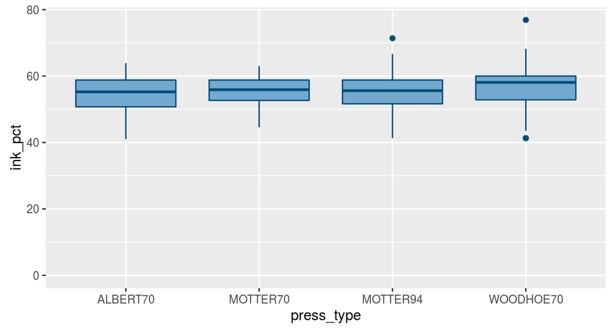

```r
pl_1 +
  scale_y_continuous(limits=c(0, max(bands$ink_pct)))
```

Because modifying limits is such a common task, `ggplot2` provides three shorthand: `ylim()`, `xlim()` and `lims()`.

The following two code lines produce equal results than the previous example:

```r
pl_1 +
  ylim(0, max(bands$ink_pct))

pl_1 +
  lims(y = c(0, max(bands$ink_pct)))
```

If you want to set only one limit, the other has to be set equal to `NA`. `ggplot2` computes automatically the not setted limit from the range of data:

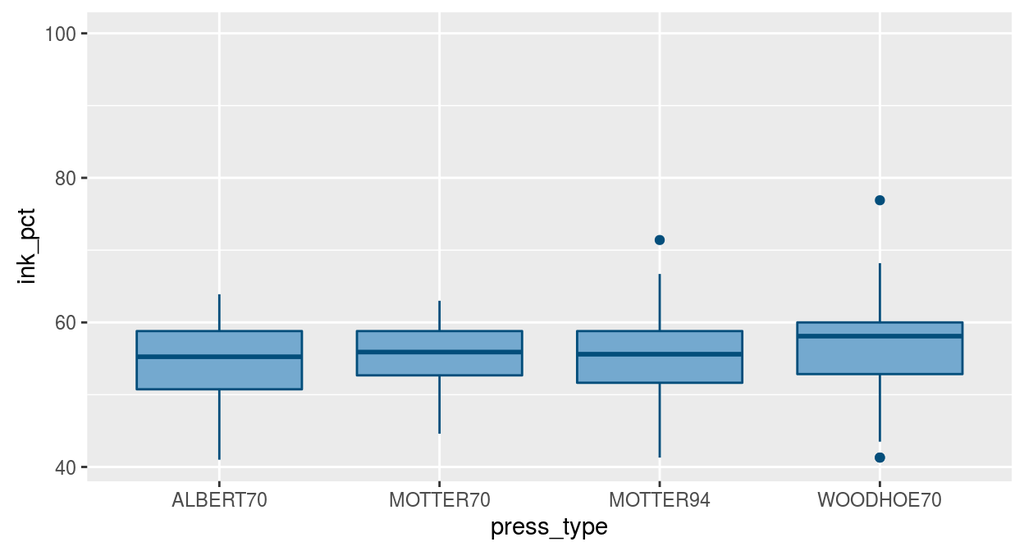

```r
pl_1 +
  ylim(limits=c(NA, 100))
```

Sometimes using `ylim()` and `scale_y_continuous()` to set other properties can create problems (the same goes for `scale_x_continuous()` and `xlim`), because only the last of the directives will have an effect. In the following two examples, `ylim(0, 100)` should set the y range from 0 to 100, and `scale_y_continuous(breaks=c(0, 50, 100))` should put tick marks at 0, 50, and 100. However, in both cases, only the second directive has any effect:

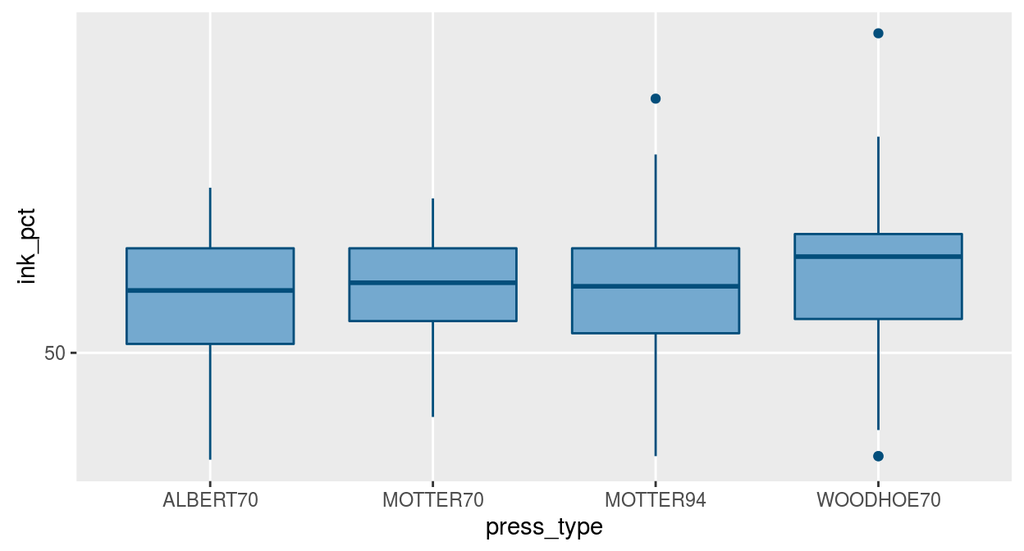

```r
pl_1 +
  ylim(0, 100) +
  scale_y_continuous(breaks=c(0, 50, 100))
```

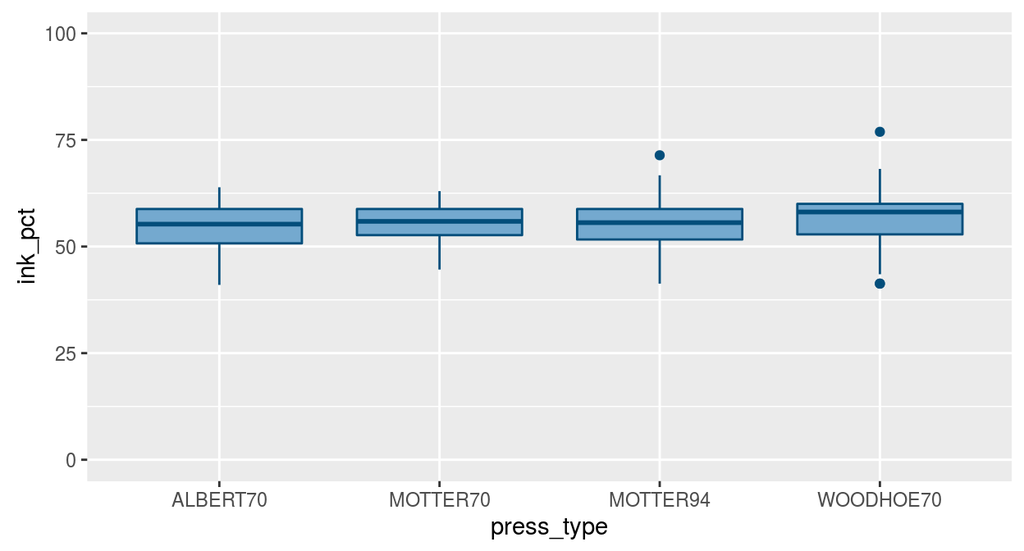

```r
pl_1 +
  scale_y_continuous(breaks=c(0, 50, 100)) +
  ylim(0, 100)
```

To make both changes work, we suggest you to set both limits and breaks in `scale_y_continuous()`:

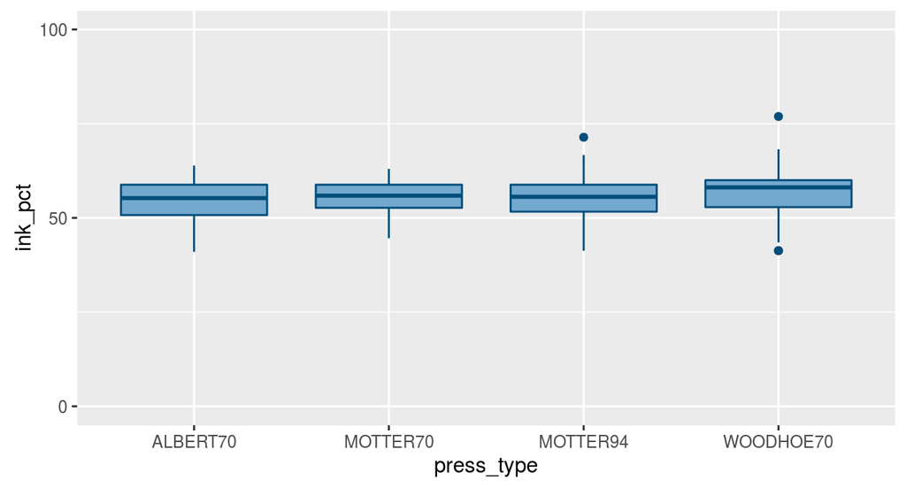

```r
pl_1 +
  scale_y_continuous(limits=c(0, 100), breaks=c(0, 50, 100))
```

We saw that modifying the scale for changing axes limits works well. However, when you modify the limits of the x or y scale, any data outside of the limits is removed that is, the out-of-range data is not only not displayed, it is removed from consideration entirely.  
With the Box Plots in these examples, if you restrict the y range so that some of the original data is clipped, the box plot statistics will be computed based on clipped data, and the shape of the box plots will change.  
With a coordinate transformation for changing limits, the data is not clipped; in essence, it zooms in or out to the specified range.  
Let us see the difference between these two methods:

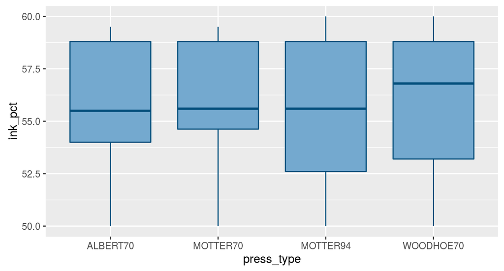

```r
# scale transformation method
pl_1 +
  scale_y_continuous(limits = c(50, 60))
```

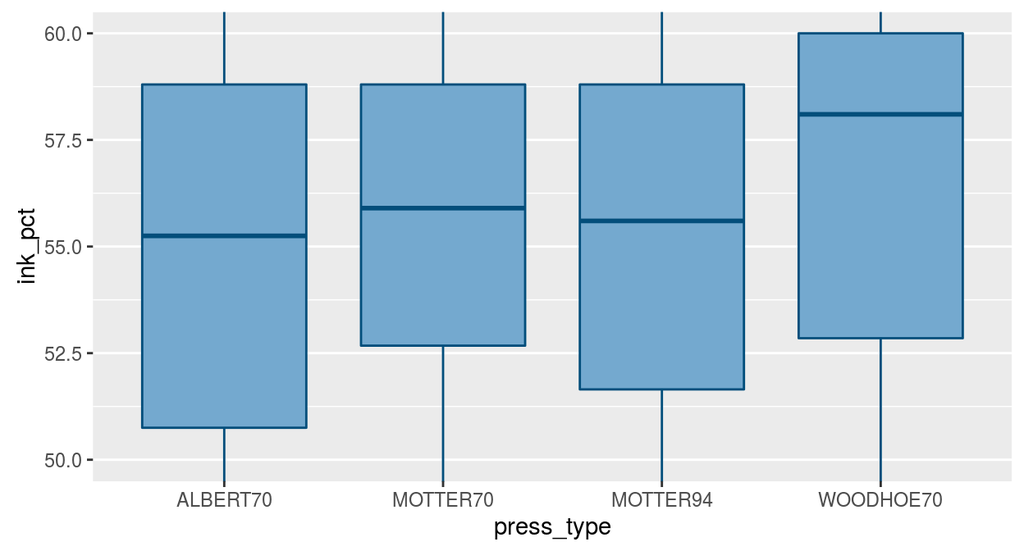

```r
# coordinate transformation method
pl_1 +
  coord_cartesian(ylim = c(50, 60))
```

## Reverse a continuous axis order

To reverse a continuous axes the function to use are: `scale_y_reverse()` or `scale_x_reverse()`:

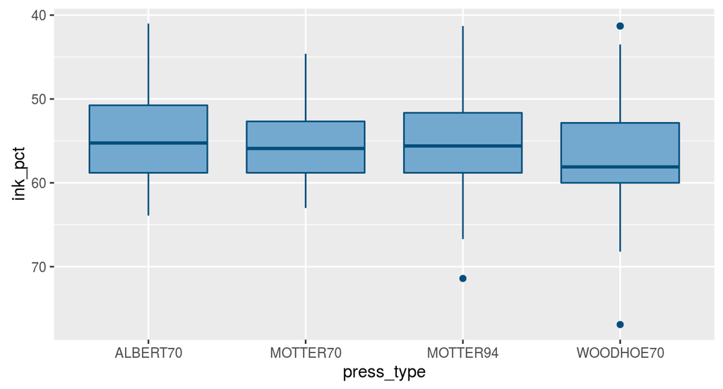

```r
pl_1 +
  scale_y_reverse()
```

You can use also `ylim()` in this way:

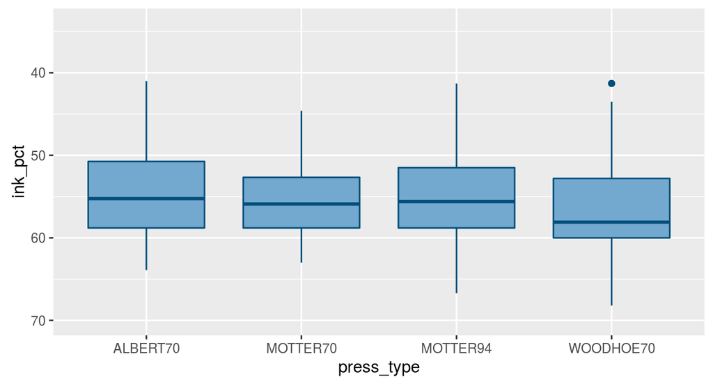

```r
pl_1 +
  ylim(70, 34)
```

Like `scale_y_continuous()`, `scale_y_reverse()` does not work with `ylim()`. (The same is true for the x-axis properties.) If you want to reverse an axis and set its range, you must do it within the `scale_y_reverse()` statement, by setting the limits in reversed order:

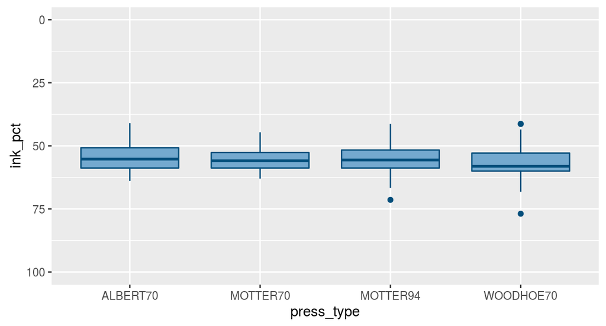

```r
pl_1 +
  scale_y_reverse(limits=c(100, 0))
```

## Resize axis scale

Suppose you are interested in the relationship between ink and solvent percentage in `bands` dataset:

```r
pl_2 <- ggplot(data = bands, mapping = aes(y=ink_pct, x=solvent_pct)) +
  geom_point()
```

If you want the same scale for your axes, you have to use `coord_equal()` function.

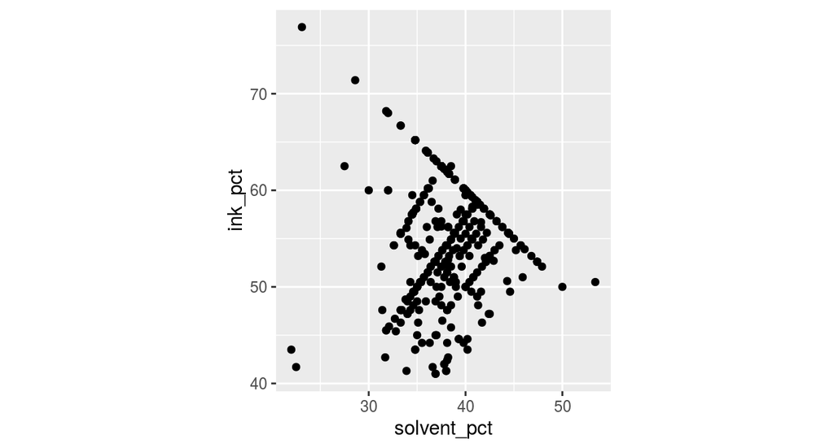

```r
pl_2  +
  coord_equal()
```

By default `ratio` argument is set to 1, which ensures that one unit on the x-axis is the same length as one unit on the y-axis.

You can change it as you want to resize the scales:

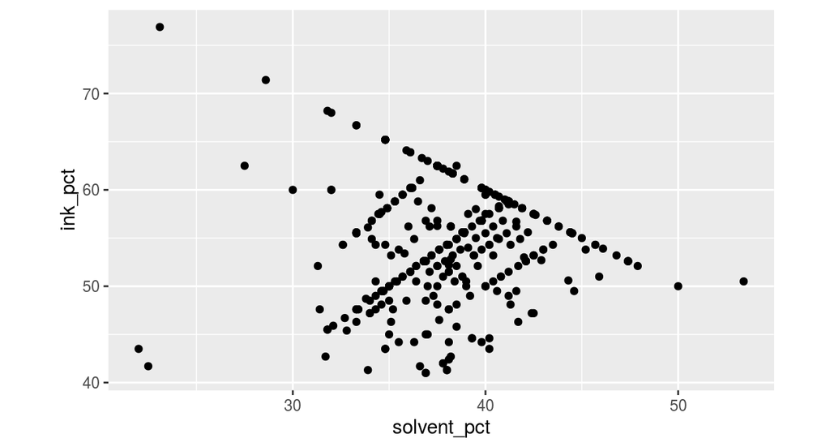

```r
pl_2  +
  coord_equal(ratio=1/2)
```

You can use also `coord_fixed()` to achieve the same results.

## Axis scale transformations

`brainbod` dataset contains information about the weight of body and brain of different species of animals. We wants to visualize the relationship between body weight and brain weight of 15 animals species:

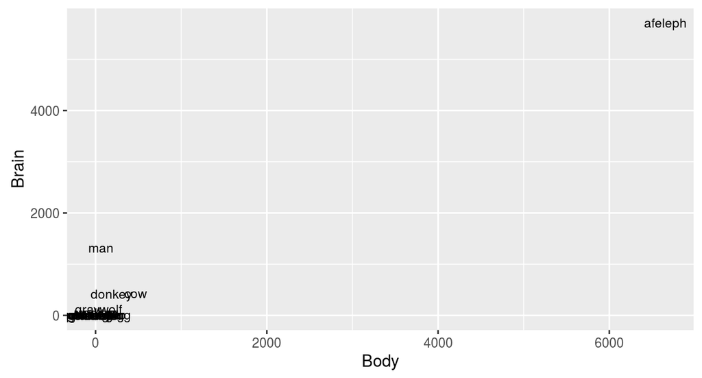

```r
pl_3 <- ggplot(brainbod, aes(x=Body, y=Brain, label=Species)) +
geom_text(size=3)
pl_3
```

With the default linearly scaled axes, it’s hard to make much sense of this graph. Because of the presence of elephant, the rest of the animals get squished into the lower-left corner of the graph. This is a case where the data is distributed exponentially on both axes, so a logarithmic transformations is the best solution. `scale_x_log10()` and `scale_y_log10()` functions are continuous position scales which transform x and y axis scales respectively.

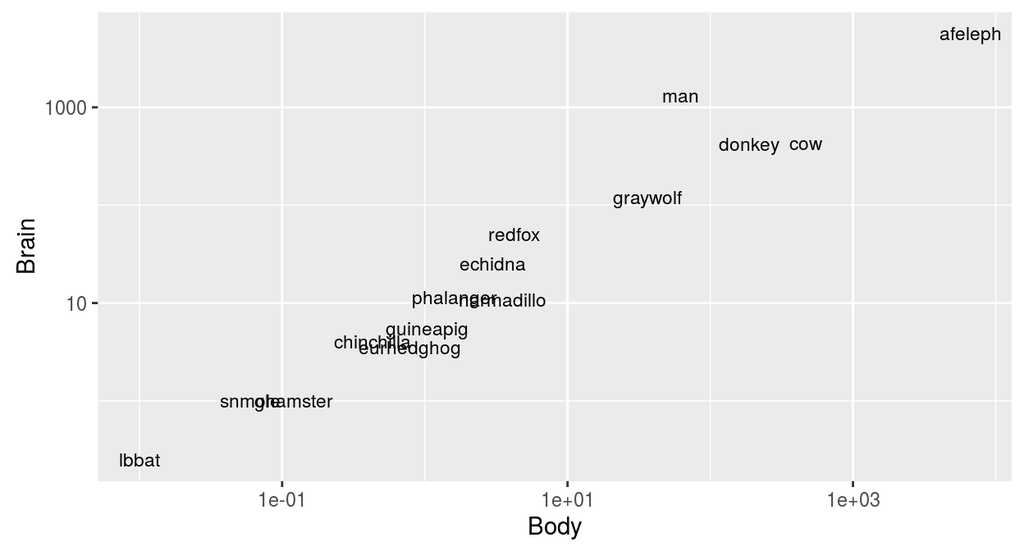

```r
pl_3 +
  scale_x_log10() +
  scale_y_log10()
```

Now the plot results are intrepretable, we clearly see a linear relationship between brain weight and body weight of the analyzed animal species.

The previous example used a $log_{10}$ transformation, but it is possible to use other transformations, such as $log_{2}$ and natural log. `scale_x_log10()` (and similarly for y) is a shortcut as it is one of the most common trasformations. A wide variety of transformations can be applied to scales of continuous axes, by setting `trans` argument of `scale_x_continuous()` and/or `scale_y_continuous()`.

Let us apply natural logarithmic transformation to x axis and $log_{2}$ transformation to y axis:

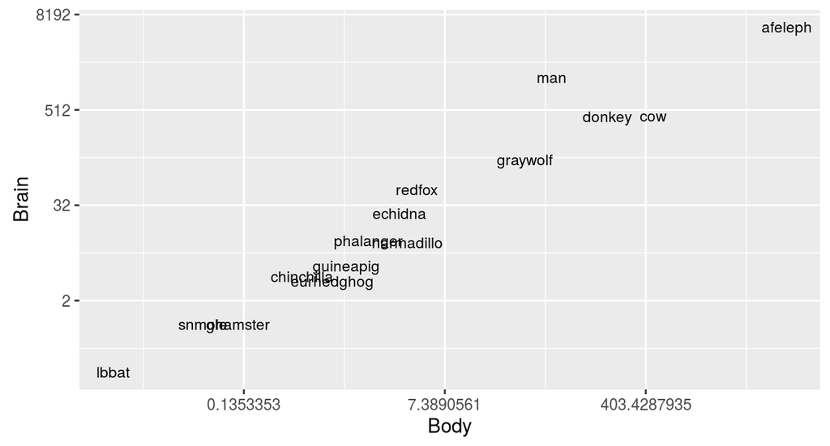

```r
pl_3 +
  scale_x_continuous(trans = log_trans()) +
  scale_y_continuous(trans = log2_trans())
```

## Modifying axis appearance: tick labels, tick marks, and the grid lines

There are actually three related items that can be controlled: tick labels, tick marks, and the grid lines. For continuous axes, `ggplot()` normally places a tick label, tick mark, and major grid line at each value of breaks. For categorical axes, these things go at each value of limits.

### Change Tick marks position

Usually `ggplot()` does a good job of deciding where to put the tick marks, but if you want to change them, set breaks in the scale in this way:

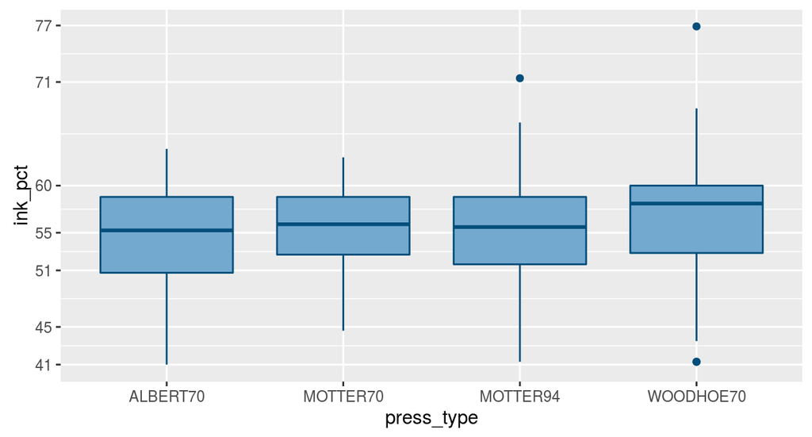

```r
pl_1 +
  scale_y_continuous(breaks=c(41, 45, 51, 55, 60, 71, 77))
```

The location of the tick marks defines where major grid lines are drawn. If the axis represents a continuous variable, minor grid lines, which are fainter and unlabeled, will by default be drawn halfway between each major grid line. If the axis is discrete instead of continuous, then there is by default a tick mark for each item.

For discrete axes, you can change the order of items or remove them by specifying the limits as learn in *Change axis order* paragraph. Setting breaks will change which of the levels are labeled, but will not remove them or change their order.

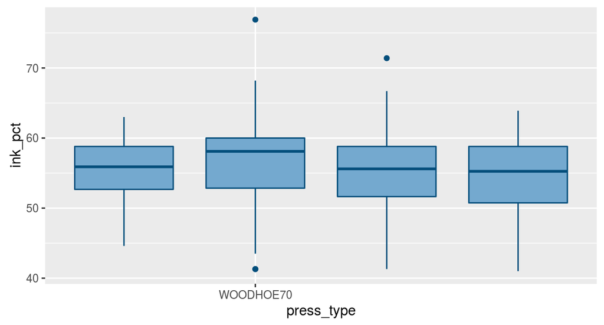

```r
pl_1 +
  scale_x_discrete(limits=c("MOTTER70","WOODHOE70", "MOTTER94", "ALBERT70"), breaks="WOODHOE70")
```

### Removing Tick Marks and Labels

The theme function for the removal of both tick marks and labels is `element_blank()`.

`axis.text.x`, `axis.text.y` and `axis.text` arguments of `theme()` function controls the text of x, y or both axis ticks.

To remove just the tick labels of both axes use `theme(axis.text = element_blank())`, and to remove the tick labels of y axes use `theme(axis.text.y = element_blank())` (or do the same for `axis.text.x`). This will work for both continuous and categorical axes:

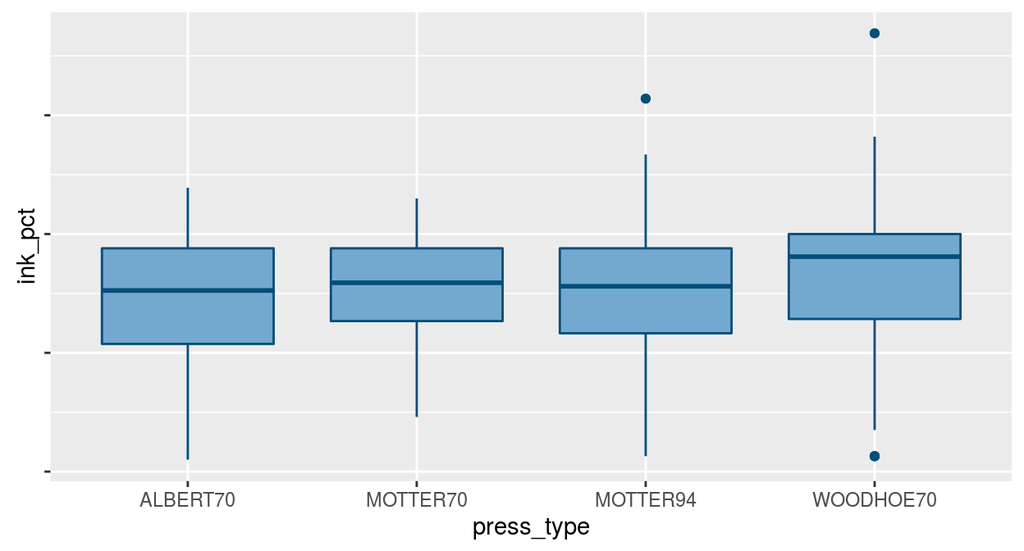

```r
pl_1 +
  theme(axis.text.y = element_blank())
```

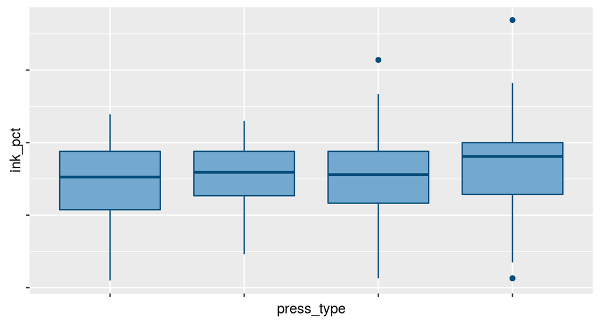

```r
pl_1 +
  theme(axis.text = element_blank())
```

`axis.ticks.x`, `axis.ticks.y` and `axis.ticks` controls the marks of x, y or both axis ticks.

To remove the tick marks on both axes, use `theme(axis.ticks=element_blank())`, and to remove the tick marks of y axes use `theme(axis.ticks.y=element_blank())`. This will remove the tick marks.

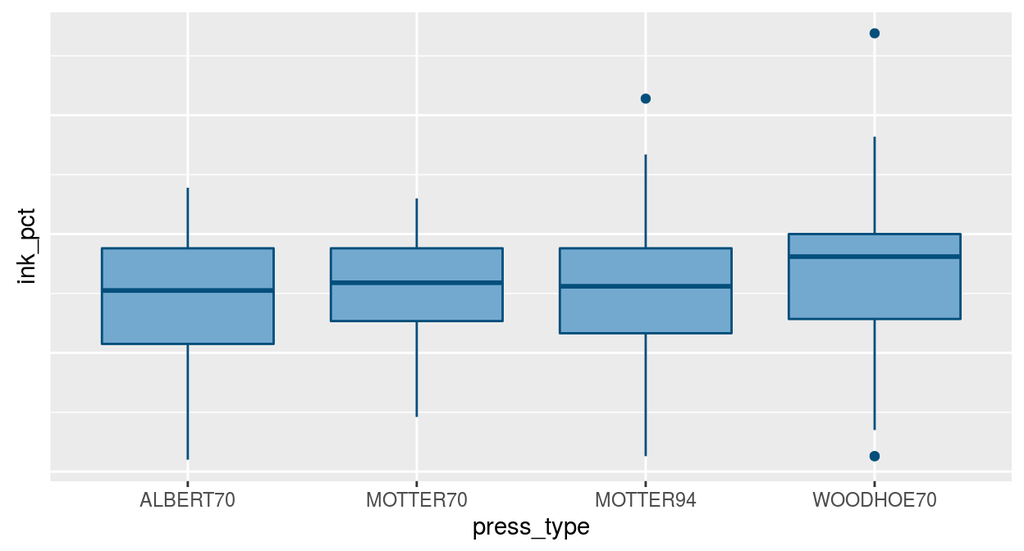

```r
pl_1 +
  theme(axis.ticks.y = element_blank(), axis.text.y = element_blank())
```

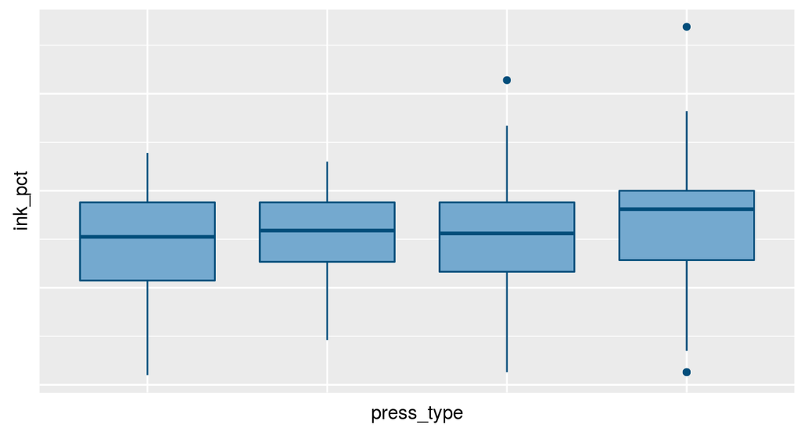

```r
pl_1 +
  theme(axis.ticks = element_blank(), axis.text = element_blank())
```

To remove the tick marks, the labels, and the grid lines for continuous axis, set `breaks` to `NULL` in `scale_y_continuous` (the same for `scale_x_continuous`).

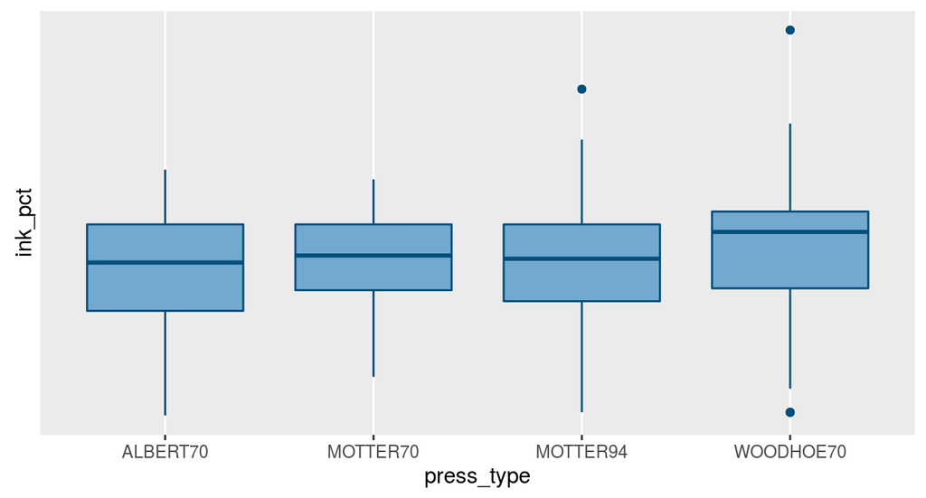

```r
pl_1 +
  scale_y_continuous(breaks=NULL)
```